# Econometría II

v. 2026.03.22

PDF

## Regresores estocásticos

## Regresores estocásticos (1/6)

Consideremos el modelo:

\[ \mathbf{y}=\mathbf{x}\boldsymbol{\beta}+\mathbf{u} \]

Y supongamos que el vector \(\mathbf{x}\) es estocástico. En este caso:

\[ \begin{align} \mathbb{E}(\mathbf{b}) = & \boldsymbol{\beta}+ \mathbb{E}[\mathbf{(x'x)}^{-1}(\mathbf{x'u})]\\[6pt] \neq & \boldsymbol{\beta}+ (\mathbf{x'x})^{-1}\mathbf{x'}\mathbb{E}(\mathbf{u}) \end{align} \]

## Regresores estocásticos (2/6)

Se puede demostrar que todas las propiedades de los estimadores de MCO se siguen satisfaciendo si suponemos que el vector \(\mathbf{x}\) y el vector \(\mathbf{u}\) son independientes. Es decir:

\[ \begin{align} \mathbb{E}(\mathbf{u}|\mathbf{x})&=\mathbb{E}(\mathbf{u})\\ &=\mathbf{0} \end{align} \]

Lo anterior nos permite calcular:

\[ \begin{align} \mathbb{E}(\mathbf{y}|\mathbf{x})= & \mathbf{x} \beta\\ \mathbb{E}(\mathbf{u'u}|\mathbf{x})= & \sigma^2 \mathbf{I}_n \end{align} \]

## Regresores estocásticos (3/6)

Ejercicio

Muestra que:

\[ \begin{align} \mathbb{E}(\mathbf{b|x}) & =\mathbb{E}(\mathbf{b}) \\ &=\beta\\ \text{var}(\mathbf{b|x})&=\sigma^2(\mathbf{x'x})^{-1}\\ \text{var}(\mathbf{b})& = \sigma^2 \mathbb{E}[(\mathbf{x'x})^{-1}]\\ \mathbb{E}(s^2|\mathbf{x})&=\mathbb{E}(s^2)\\ &=\sigma^2\\ \end{align} \]

Lo anterior implica que el *teorema de Gauss-Markov* sigue siendo válido cuando las \(\mathbf{x}\) son estocásticas. ¿Por qué? (\(\textbf{Pista}\): Usa la **ley de las expectativas iteradas**.)

## Regresores estocásticos (4/6)

Cuando las \(\mathbf{x}\) son estocásticas, tambien resulta importante suponer que:

\[ \begin{align} & p\lim \left(\frac{1}{n}\mathbf{u'u}\right)=\mathbf{\Omega}\\[8pt] & p\lim \left(\frac{1}{n}\mathbf{x'x}\right)=\mathbf{Q}\\[8pt] & p\lim \left(\frac{1}{n}\mathbf{x'u}\right)=\mathbf{0} \end{align} \]

## Regresores estocásticos (5/6)

Ejercicio

Muestra que el estimador de MCO para \(\beta\) sigue siendo consistente cuando las \(\mathbf{x}\) son estocásticas.

## Regresores estocásticos (6/6)

Ejercicio

Definamos la matriz de varianzas y covarianzas asintótica de \(\mathbf{b}\) como:

\[ \text{asy var}(\mathbf{b})=\frac{1}{n} \lim_{n\rightarrow\infty}\mathbb{E}[\sqrt{n}(\mathbf{b}-\beta)][\sqrt{n}(\mathbf{b}-\beta)]' \]

Muestra que esta es igual a:

\[ \text{asy var}(\mathbf{b})= \frac{1}{n}\sigma^2 \mathbf{Q}^{-1} \]

Nota. Calcula el siguiente límite y comenta.

\[ \lim_{n\rightarrow\infty}\mathbb{E}[(\mathbf{b}-\beta)][(\mathbf{b}-\beta)]' \]

## Errores de medición en los regresores

## Erorres de medición, x’s (1/5)

Supongamos que el modelo verdadero es:

\[ y_i=\beta_1+\beta_2z_i + v_i \]

Sin embargo no observamos \(z_i\). En su lugar observamos:

\[ x_i=z_i+w_i \]

## Erorres de medición, x’s (2/5)

Suponemos que:

\[ V_i\sim iid\mathcal{N}(0,\sigma^2_V)\;; \quad V=v, w, z \]

Además:

\[ v\perp w; \quad v\perp z; \quad w \perp z \]

y:

\[ p \lim \frac{1}{n}\sum_{i=1}^{n}(V_i-\overline{V})^2=\sigma_V^2 \]

## Erorres de medición, x’s (3/5)

La información disponible nos permite reescribir el modelo en una forma más conocida:

\[ \begin{align} y_i= & \beta_1+\beta_2x_i+u_i;\\[5pt] u_i= & v_i - \beta_2 w_i \end{align} \]

Nota sin embargo que al estimar por MCO:

\[ \begin{align} \mathbb{E}(b_2)&=\beta_2+\mathbb{E}\left(\frac{\text{cov}(x,u)}{\text{var(x)}}\right) \\ &\neq \beta_2 \end{align} \]

Esto se debe a que \(x\) y \(u\) *no son independientes*. En otras palabras, nos enfrentamos a un problema de **endogeneidad**.

## Erorres de medición, x’s (4/5)

Dado que no podemos calcular la distribución exacta de \(b_2\), nos concentraremos en ver qué pasa cuando el número de observaciones tiende a infinito. Se puede demostrar que:

\[ p\lim(b_2)=\beta_2-\beta_2\frac{\sigma_w^2}{\sigma_z^2+\sigma_w^2} \]

Por lo tanto el sesgo de \(b_2\) (para muestras grandes) es:

\[ \text{Sesgo}=-\beta_2\frac{\sigma_w^2}{\sigma_z^2+\sigma_w^2} \]

el cual depende del signo de \(\beta_2\).

## Erorres de medición, x’s (5/5)

Ejercicio

Muestra que:

\[ p\lim(b_2)=\beta_2-\beta_2\frac{\sigma_w^2}{\sigma_z^2+\sigma_w^2} \]

Nota. ¿Qué pasa si introducimos en el modelo una *variable proxy imperfecta*?

## Simulación (1/2)

Una simulación nos muestra los efectos de los errores de medición en los regresores. Sea el modelo verdadero:

\[ y_i=2+0.8z_i+\nu_i \\ x_i=z_i+\omega_i\\ z_i\sim\mathcal{N}(10,4)\\ \nu_i\sim\mathcal{N}(0,4)\\ \omega_i\sim \mathcal{N}(0,1) \]

Ejercicio

Muestra que si usamos \(x_i\) en lugar de \(z_i\) en la regresión, obtendremos que: \(p \lim(b_2)=0.64\).

## Simulación (2/2)

La siguiente gráfica nos muestra la distribución de \(b_2\) para \(n=1000\).

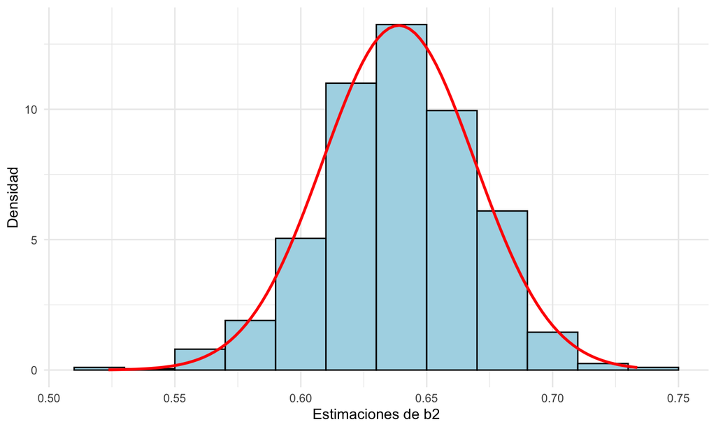

## Errores de medición en la variable dependiente

## Errores de medición, y (1/5)

Supongamos que el modelo verdadero es:

\[ Q_i=\beta_1+\beta_2x_i+\varepsilon_i \]

Sin embargo no observamos \(Q_i\). En su lugar observamos:

\[ y_i=Q_i+\psi_i \]

## Errores de medición, y (2/5)

Suponemos que:

\[ W_i\sim iid\mathcal{N}(0,\sigma_W^2); \quad W=\varepsilon, x, \psi \]

Además:

\[ \varepsilon\perp x; \quad \varepsilon \perp \psi; \quad x \perp \psi \]

y:

\[ p \lim \frac{1}{n}\sum_{i=1}^{n}\left(W_i-\overline{W}\right)^2=\sigma_W^2 \]

## Errores de medición, y (3/5)

Ejercicio

Muestra que, cuando la variable dependiente está medida con error, los estimadores de MCO siguen siendo insesgados. Es decir:

\[ \mathbb{E}(b_2)=\beta_2 \]

## Errores de medición, y (4/5)

Aunque los estimadores de MCO siendo insesgados, se puede demostrar que son ineficientes (para muestras grandes). En particular, se puede demostrar que:

\[ \sigma_{b_2}^2=\frac{\sigma_{\varepsilon}^2+\sigma_{\psi}^2}{n\sigma_s^2}\geq\frac{\sigma_{\varepsilon}^2}{n\sigma_x^2} \]

## Errores de medición, y (5/5)

Ejercicio

Muestra que, para muestras grandes:

\[ \sigma_{b_2}^2=\frac{\sigma_{\varepsilon}^2+\sigma_{\psi}^2}{n\sigma_x^2} \]

Nota. ¿Qué pasa si tanto \(x_i\) como \(y_i\) están sujetas a errores de medición?

## Variables Instrumentales (IV)

## Variables instrumentales (1/2)

Imaginemos que:

\[ p\lim\left(\frac{1}{n}\mathbf{x'u}\right)\neq \mathbf{0} \]

En este caso, el estimador de MCO *deja de ser consistente*:

\[ \begin{align} p\lim(\mathbf{b})&=\boldsymbol{\beta}+p\lim\left(\frac{1}{n}\mathbf{x'x}\right)^{-1}\cdot p\lim\left(\frac{1}{n}\mathbf{x'u}\right)\\ &\neq \boldsymbol{\beta} \end{align} \]

## Variables instrumentales (2/2)

Sin embargo, supongamos que existe u vector de variables \(\mathbf{z}\) *de la misma dimensión* que \(\mathbf{x}\), tal que:

\[ \begin{align} & p\lim\left(\frac{1}{n}\mathbf{z'u}\right)=\mathbf{0}\\ & p\lim\left(\frac{1}{n}\mathbf{z'x}\right)=\boldsymbol{\Sigma}\\ & p\lim\left(\frac{1}{n}\mathbf{z'z}\right)=\boldsymbol{\Sigma}^* \end{align} \]

donde las matrices \(\boldsymbol{\Sigma}\) y \(\boldsymbol{\Sigma}^*\) deben existir y ser no singulares. Las variables en \(\mathbf{z}\) pueden utilizarse como **instrumentos** de \(\mathbf{x}\).

## El estimador de VI (1/3)

¿Cómo utilizamos el vector de instrumentos \(\mathbf{z}\)? Supongamos que el modelo es el de siempre:

\[ \mathbf{y}=\mathbf{x}\boldsymbol{\beta}+\mathbf{u} \]

Pre multiplicamos ambos lados de la ecuación por \(\mathbf{z'}\):

\[ \begin{align} \mathbf{y}^*&=\mathbf{x}^*\boldsymbol{\beta}+\mathbf{u}^*,\\ \mathbf{y}^*&=\mathbf{z'y}\\ \mathbf{x}^*&=\mathbf{z'x}\\ \mathbf{u}^*&=\mathbf{z'u} \end{align} \]

## El estimador de VI (2/3)

Ejercicio

Muestra que si estimamos el modelo resultante por MCO obtenemos:

\[ \hat{\boldsymbol{\beta}}_{IV}=(\mathbf{z'x})^{-1}(\mathbf{z'y}) \]

que es conocido como el **estimador de variables instrumentales** de \(\boldsymbol{\beta}\).

## El estimador de VI (3/3)

Ejercicio

Muestra que el estimador de variables instrumentales de \(\boldsymbol{\beta}\) es consistente y que su varianza asintótica es:

\[ \text{asy var}(\hat{\boldsymbol{\beta}}_{IV})=\frac{1}{n}\sigma^2 \boldsymbol{\Sigma^{-1}\Sigma^*\Sigma'^{-1}} \]

Nota. En la práctica, la varianza asintótica puede estimarse como:

\[ \begin{align} \text{est asy var}(\hat{\boldsymbol{\beta}}_{IV})=\frac{1}{n}s^2\boldsymbol{\Sigma^{-1}\Sigma^*\Sigma'^{-1}}\\[9pt] s^2=\frac{1}{n-k}(\mathbf{y-x}\hat{\boldsymbol{\beta}}_{IV})'(\mathbf{y-x}\hat{\boldsymbol{\beta}}_{IV}) \end{align} \]

## Simulación (1/3)

Una simulación nos permite comparar los estimadores de MCO y de IV. Sea el modelo verdadero:

\[ \begin{align} &y_i=10+5x_i+u_i\\[5pt] &x_i=2z_i+0.5v_i+u_i\\[5pt] &z_i \sim \mathcal{N}(0,1)\\[5pt] &v_i \sim \mathcal{N}(0,1)\\[5pt] &u_i \sim \mathcal{N}(0,1) \end{align} \]

Nota que \(x_i\) no es independiente de \(u_i\) en la regresión, por lo que los estimadores de MCO estarán sesgados. ¿Podemos utilizar \(z_i\) o \(v_i\) como instrumentos de \(x_i\) en la regresión?

## Simulación (2/3)

Ejercicio

Utilizando los datos del ejemplo, muestra que si usamos a \(z_i\) como instrumento:

\[ \begin{align} p \lim b_2^{MCO}&=5.19\\ p \lim b_2^{VI}&=5 \end{align} \]

## Ejemplo (3/3)

Las siguientes gráficas comparan la distribución de \(\beta_2\) estimado por MCO y VI con n=3200.

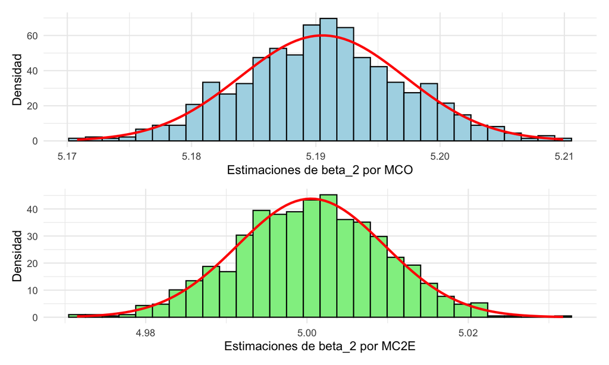

¿Qué estimador te parece mejor? ¿Por qué?

## Variables instrumentales: Ejemplo (1/2)

Ejercicio

Utiliza los datos: *E206–mroz*. Estima el modelo utilizando el método de los MCO. ¿Crees que exista un problema de endogeneidad? ¿Por qué? *Pista:* La variable endógena es la variable educación.

\[ l\text{_}wage_i=\beta_1 + \beta_2 educ_i + \beta_3 exper_i + \beta_4 exper_i^2 + u_i \]

## Variables instrumentales: Ejemplo (2/2)

En el ejemplo anterior, estimamos los coeficientes utilizando la variable *mothereduc*, que representa la educación de la mamá de la \(i\)-ésima observación. (¿Por qué?)

```
##
## Call:
## ivreg(formula = log(wage) ~ educ + exper + I(exper^2) | mothereduc +     exper + I(exper^2), data = data, subset = (wage > 0))
##
## Coefficients:
## (Intercept)         educ        exper   I(exper^2)
##   0.1981861    0.0492630    0.0448558   -0.0009221
```

## Mínimos cuadrados en dos etapas (2SLS)

## Mínimos cuadrados en dos etapas (1/4)

¿Qué pasa si contamos con más instrumentos que variables explicativas?

Sea:

\[ \mathbf{z}=\{\mathbf{z}_1 \quad \mathbf{z}_2 \ldots \mathbf{z}_l\} \]

donde \(l\geq k\). En este caso, podemos usar el método de los **mínimos cuadrados en dos etapas**.

## Mínimos cuadrados en dos etapas (2/4)

1. Estimamos una regresión por cada variable explicativa usando el método de los mínimos cuadrados ordinarios:

\[ \mathbf{x}_j=\mathbf{z}\boldsymbol{\delta}_j+\mathbf{e}_j \] donde:

\[ \boldsymbol{\delta}_j= \begin{pmatrix} \delta_{j1} \\ \delta_{j2}\\ \vdots \\ \delta_{jl} \end{pmatrix}, \quad j= 1,2,\ldots, k \]

## Mínimos cuadrados en dos etapas (3/4)

2. Recuperamos los valores ajustados: \[ \hat{\mathbf{x}}_j=\mathbf{z}\hat{\boldsymbol{\delta}}_j \]

donde:

\[ \hat{\boldsymbol{\delta}}_j=(\mathbf{z'z})^{-1}(\mathbf{z'x}_j) \]

Y, naturalmente:

\[ \begin{align} \mathbf{x}_j=& \mathbf{z}\hat{\boldsymbol{\delta}}_j+\hat{\mathbf{e}}_j\\ =& \hat{\mathbf{x}}_j +\hat{\mathbf{e}}_j \end{align} \]

## Mínimos cuadrados en dos etapas (4/4)

3. Formamos el vector: \[ \hat{\mathbf{x}}=\{\hat{\mathbf{x}}_1 \quad \hat{\mathbf{x}}_2 \ldots \hat{\mathbf{x}}_k\} \]

y usamos MCO para estimar el modelo:

\[ \mathbf{y}=\hat{\mathbf{x}}\boldsymbol{\beta}+\mathbf{u} \]

De aquí obtenemos el **estimador de mínimos cuadrados en dos etapas** para \(\boldsymbol{\beta}\):

\[ \hat{\boldsymbol{\beta}}_{2SLS}=(\hat{\mathbf{x}}'\hat{\mathbf{x}})^{-1}\hat{\mathbf{x}}'\mathbf{y} \]

## Mínimos cuadrados en dos etapas: Ejemplo

En el ejemplo de antes, estimamos los coeficientes utilizando las variables *mothereduc* y *fathereduc*, donde esta útima representa la educación del papá de la \(i\)-ésima observación.

```
##
## Call:
## ivreg(formula = log(wage) ~ educ + exper + I(exper^2) | mothereduc +     fathereduc + exper + I(exper^2), data = data, subset = (wage >     0))
##
## Coefficients:
## (Intercept)         educ        exper   I(exper^2)
##    0.048100     0.061397     0.044170    -0.000899
```

## 2SLS vs. IV (1/2)

Ejercicio

Muestra que:

\[ \begin{align} 1.&\quad \mathbf{z}'\hat{\mathbf{e}}_j=0\quad j=1,2,\ldots,k\\ 2.&\quad\hat{\mathbf{x}}'_j\hat{\mathbf{e}}_j=0\quad j=1,2,\ldots,k\\ 3.&\quad\hat{\mathbf{x}}'_m\hat{\mathbf{e}}_j=0 \quad\forall \quad m\neq j, \quad j,m=1,2,\ldots,k \end{align} \]

Usando lo anterior, muestra además que:

\[ \begin{align} \hat{\boldsymbol{\beta}}_{2SLS}&=(\hat{\mathbf{x}}'\hat{\mathbf{x}})^{-1}\hat{\mathbf{x}}'\mathbf{y}\\[5pt] &= (\hat{\mathbf{x}}'\mathbf{x})^{-1}\hat{\mathbf{x}}'\mathbf{y} \end{align} \]

## 2SLS vs. IV (2/2)

Ejercicio

Demuestra que las estimaciones por mínimos cuadrados en dos etapas y por variables instrumentales son equivalentes cuando tenemos igual número de instrumentos que de variables endógenas. Es decir:

\[ \hat{\boldsymbol{\beta}}_{2SLS}=\hat{\boldsymbol{\beta}}_{IV} \]

Nota. ¿Puedes decir cuál es la ventaja de utilizar el método de los mínimos cuadrados en dos etapas?

## Selección de instrumentos

## Instrumentos fuertes (1/3)

Para seleccionar los instrumentos, primero tenemos que asegurarnos que la correlación entre estos y las variables que van a instrumentar sea alta.

Para ver lo anterior, considera el estimador de variables instrumentales:

\[ \begin{align} \hat{\boldsymbol{\beta}}_{IV}&= (\hat{\mathbf{z}}'\hat{\mathbf{x}})^{-1}(\hat{\mathbf{z}}'\mathbf{y}) \\ &=\boldsymbol{\beta}+(\hat{\mathbf{z}}'\hat{\mathbf{x}})^{-1}(\hat{\mathbf{z}}'\mathbf{u}) \end{align} \]

O, en un modelo de regresión simple:

\[ \hat{\beta}_{2,IV}=\beta_2+\frac{\text{cov}(z,u)}{\text{cov}(z,x)} \]

Cuando la cov(\(z,x\)) se acerca a cero, el sesgo del estimador de \(\boldsymbol{\beta}\) se acerca a infinito. En este caso decimos que \(z\) es un instrumento débil de \(x\). Es fuerte en caso contrario.

## Instrumentos fuertes (2/3)

Para hacer una prueba seria para **instrumentos fuertes**, supongamos que \(x_k\) es endógena y que contamos con un instrumento \(z_1\). Entonces:

- Corremos la regresión (que corresponde a la primera etapa del método de 2SLS):

\[ x_k=\gamma_1+\gamma_2x_2+\ldots+\gamma_{k-1}x_{k-1}+\theta_1z_1+\nu_k \]

- Para que el instrumento \(z_1\) sea fuerte, es necesario que el coeficiente \(\theta_1\) sea (muy) significativo. Como regla de uso común, esto será el caso *si el estadístico \(F\) de la prueba de significancia \(H_0: \theta_1=0\) es mayor a 10*.

## Instrumentos débiles (3/3)

- Naturalmente, en caso de tener *L* instrumentos, corremos la siguiente regresión:

\[ x_k=\gamma_1+\gamma_2x_2+\ldots+\gamma_{k-1}x_{k-1}+\theta_1z_1+\dots+\theta_lz_l+\nu_k \]

- En este caso, el estadístico \(F\) de la prueba \(\theta_1=\theta_2=\ldots=\theta_L=0\) tiene que ser mayor a 10.

En el ejemplo anterior tenemos:

```
##                  df1 df2 statistic      p-value
## Weak instruments   2 423   55.4003 4.268909e-22
```

## Los instrumentos deben ser exógenos

La relación anterior también deja en claro que el sesgo del estimador de \(\boldsymbol{\beta}\) tiende a cero conforme la \(cov(z,u)\) se acerca a cero. Cuando esto ocurre decimos que tenemos **instrumentos exógenos**.

Una forma de saber si tenemos instrumentos exógenos es realizando la **prueba de Sargan**.

## Prueba de Sargan (1/3)

Para realizar la prueba de Sargan:

- Calculamos los estimadores de variables instrumentales:

\[ \hat{\boldsymbol{\beta}}_{IV}=(\mathbf{z}'\mathbf{x}')^{-1}(\mathbf{z}'\mathbf{y}) \]

- Recuperamos los residuales:

\[ \mathbf{e}_{IV}=\mathbf{y}-\mathbf{x}\hat{\boldsymbol{\beta}}_{IV} \]

## Prueba de Sargan (2/3)

- Corremos la siguiente regresión:

\[ \mathbf{e}_{IV}= \mathbf{z}\gamma+v \]

- Calculamos el estadístico \(nR^2\), donde \(n\) es el tamaño de la muestra y \(R^2\) es el coeficiente de determinación de la regresión precedente. Tenemos que:

\[ nR^2\sim \chi^2_{(l-k \; g.l)} \] donde \(l\) es el número de instrumentos y \(k\) es el número de variables endógenas.

- El punto anterior implica que, para que la prueba de Sargan pueda realizarse, es necesario tener más instrumentos que variables endógenas \(l>k\). Por esta razón, a la prueba de Sargan también se le conoce como **prueba de sobre identificación**.

## Prueba de Sargan (3/3)

- Realizamos la siguiente prueba:

\[ \begin{align} H_0\; :& \quad \text{cov}(\mathbf{z},\mathbf{e}_{IV})=0\\ H_1\; :& \quad \text{cov}(\mathbf{z},\mathbf{e}_{IV})\neq 0 \end{align} \] Naturalmente, *si rechazamos \(H_0\)* los instrumentos no son exógenos. En nuestro ejemplo de antes tenemos:

```
##        df1 df2 statistic   p-value
## Sargan   1  NA 0.3780715 0.5386372
```

## Prueba de Hausman (1/5)

Finalmente, también necesitamos una prueba para saber si nuestra regresión debe estimarse por el método de las variables instrumentales, o si el método de los MCO es suficiente.

La prueba que debemos realizar en este caso se conoce como la **prueba de Hausman**.

## Prueba de Hausman (2/5)

Para mostrar como funciona la prueba de Hausman, supongamos que el modelo es:

\[ y_i=\beta_1+\beta_2x_i+u_i \]

y sospechamos que podría haber una relación entre \(x_i\) y \(u_i\). Suponemos que tenemos dos buenos instrumentos para \(x_i\): \(z_1\) y \(z_2\).

## Prueba de Hausman (3/5)

- Estimamos por MCO la siguiente ecuación:

\[ x_i=\gamma_1+\theta_1z_{1i}+\theta_2z_{2i}+v_i \] y recuperamos los residuales:

\[ \hat{v_i}= x_i - \hat{\gamma_1}-\hat{\theta}_1z_{1i}-\hat{\theta}_2z_{2i} \]

## Prueba de Hausman (4/5)

- Ahora estimamos por MCO:

\[ y_i=\beta_1 + \beta_2x_i + \delta\hat{v}_i+\nu_i \] Una *prueba \(t\)* nos permitirá probar la siguiente hipótesis:

\[ \begin{align} H_0 \; &: \quad \delta=0\\[6pt] H_1\; &: \quad \delta\neq 0 \end{align} \]

Si rechazamos \(H_0\) el método de las variables instrumentales es apropiado. De otra forma usamos MCO.

¿Por qué?

## Prueba de Hausman (5/5)

En el ejemplo de antes tenemos:

```
##            df1 df2 statistic    p-value
## Wu-Hausman   1 423  2.792592 0.09544055
```

Nota.

En caso de tener más de una variable explicativa relacionada con el error, \(u\), hacemos tantas regresiones como sea necesario en el paso 1 e incluimos los residuales de estas en la regresión del paso 2. La prueba de hipótesis en este caso implicaría el uso de una *\(F\)* en lugar de una *\(t\)*.

## Práctica

## Práctica

Utilia los datos: *E207–fertility* para explicar ¿cómo afecta la fertilidad a la oferta de trabajo? Es decir, ¿cuánto disminuye la oferta de trabajo de una mujer cuando tiene un hijo más?

\[ \begin{align} &\text{morekids = 1 if mom had more than 2 children}\\ &\text{boy1st = 1 if 1st child was a boy}\\ &\text{boy2nd = 1 if 2nd child was a boy}\\ &\text{samesex = 1 if 1st two children same sex}\\ &\text{agem1 = age of mom at census}\\ &\text{black = 1 if mom is black}\\ &\text{hispan = 1 if mom is Hispanic}\\ &\text{othrace = 1 if mom is not black, Hispanic or white}\\ &\text{weeksm1 = mom's weeks worked in 1979} \end{align} \]

Realiza un análisis completo del modelo: